# Modelo predictivo de SAIDI y SAIFI por cuadrante-semana

# Parte 10 — Modelo de conteo: usuarios_afectados como variable de naturaleza discreta

## Por qué un modelo de conteo, y qué problema resuelve

Se modela `usuarios_afectados` directamente (no `log_SAIDI1`), usando **todas** las semanas del panel (no solo las que tuvieron falla, a diferencia de los modelos anteriores) — un modelo de conteo debe ver también los ceros para estimar correctamente la probabilidad de que ocurra un evento.

## Paquetes adicionales

```r
if (!requireNamespace("pscl", quietly = TRUE)) install.packages("pscl")
```

```
##
##  C:\Users\ESILVAS\AppData\Local\Temp\Rtmpa6alNx\downloaded_packages
```

```r
if (!requireNamespace("performance", quietly = TRUE)) install.packages("performance")
```

```
##
##  C:\Users\ESILVAS\AppData\Local\Temp\Rtmpa6alNx\downloaded_packages
```

```r
library(pscl)         # para test de sobredispersión y modelos zero-inflated
library(performance)  # chequeo de sobredispersión más directo
```

## Preparación de datos: todas las semanas, no solo con falla

```r
data_conteo <- data_final %>%
  filter(!is.na(usuarios_afectados), !is.na(id_cuadrante), !is.na(semana))

cat(sprintf(
  "Filas totales: %d | Semanas con usuarios_afectados = 0: %d (%.1f%%) | Con falla: %d (%.1f%%)\n",
  nrow(data_conteo),
  sum(data_conteo$usuarios_afectados == 0), 100 * mean(data_conteo$usuarios_afectados == 0),
  sum(data_conteo$usuarios_afectados > 0), 100 * mean(data_conteo$usuarios_afectados > 0)
))
```

```
## Filas totales: 36120 | Semanas con usuarios_afectados = 0: 22768 (63.0%) | Con falla: 13352 (37.0%)
```

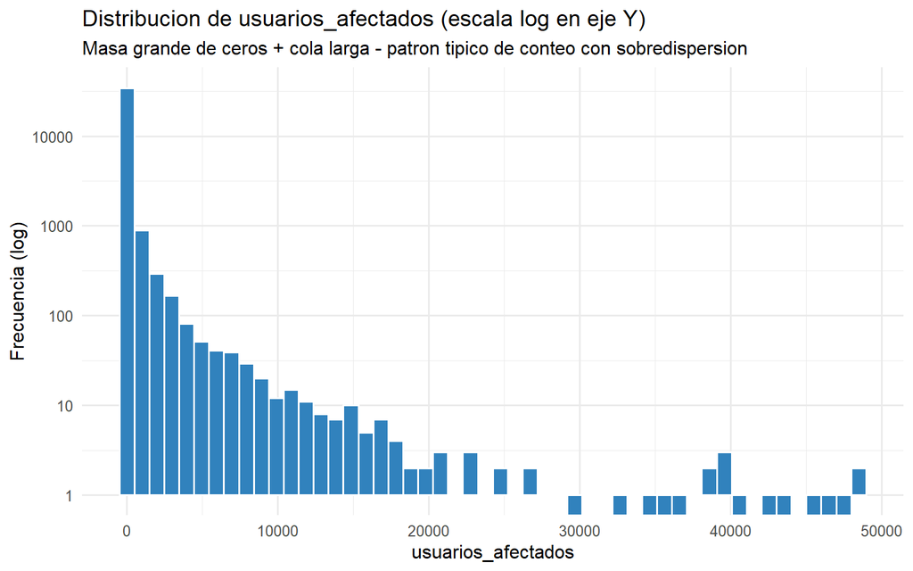

```r
ggplot(data_conteo, aes(x = usuarios_afectados)) +
  geom_histogram(bins = 50, fill = "#3182bd", color = "white") +
  scale_y_log10() +
  labs(
    title    = "Distribucion de usuarios_afectados (escala log en eje Y)",
    subtitle = "Masa grande de ceros + cola larga - patron tipico de conteo con sobredispersion",
    x = "usuarios_afectados", y = "Frecuencia (log)"
  ) +
  theme_minimal(base_size = 12)
```

## Split temporal (mismo criterio que en el resto del documento)

```r
train_conteo <- data_conteo %>% filter(semana <= corte)
test_conteo  <- data_conteo %>% filter(semana >  corte)

cat(sprintf("Train: %d filas | Test: %d filas\n", nrow(train_conteo), nrow(test_conteo)))
```

```
## Train: 30616 filas | Test: 5504 filas
```

## Modelo 1 — Poisson

Se usan las mismas variables de `vars_modelo` (Parte 4), reemplazando `SAIDI_lag1` por un rezago propio de `usuarios_afectados`.

```r
train_conteo <- train_conteo %>%
  group_by(id_cuadrante) %>%
  arrange(semana) %>%
  mutate(usuarios_afectados_lag1 = dplyr::lag(usuarios_afectados, 1)) %>%
  ungroup()

test_conteo <- test_conteo %>%
  group_by(id_cuadrante) %>%
  arrange(semana) %>%
  mutate(usuarios_afectados_lag1 = dplyr::lag(usuarios_afectados, 1)) %>%
  ungroup()

vars_conteo <- setdiff(vars_modelo, "SAIDI_lag1")
vars_conteo <- c(vars_conteo, "usuarios_afectados_lag1")
vars_conteo <- intersect(vars_conteo, names(train_conteo))

formula_conteo <- as.formula(paste("usuarios_afectados ~", paste(vars_conteo, collapse = " + ")))
cat("Formula del modelo de conteo:\n"); print(formula_conteo)
```

```
## Formula del modelo de conteo:
```

```
## usuarios_afectados ~ temp_media_semana + viento_max_semana +
##     precip_total_semana + precip_ma4 + ndvi_semanal + n_eventos_catastroficos +
##     n_sismos_r50 + dist_sismo_min_km_r50 + longitud_red_km +
##     densidad_terminales + prop_estrato_1 + prop_estrato_2 + prop_no_residencial +
##     edad_activo_mas_viejo_anios + PROM_CANT_MODIFICACIONES +
##     SAIDI_vecinos_lag1 + n_eventos_vecinos + ndvi_vecinos + usuarios_afectados_lag1
```

```r
modelo_poisson <- glm(formula_conteo, data = train_conteo, family = poisson(link = "log"))
summary(modelo_poisson)
```

```
##
## Call:
## glm(formula = formula_conteo, family = poisson(link = "log"),
##     data = train_conteo)
##
## Coefficients: (2 not defined because of singularities)
##                               Estimate Std. Error z value Pr(>|z|)
## (Intercept)                  1.073e+00  1.018e-02  105.38   <2e-16 ***
## temp_media_semana            1.149e-01  1.736e-04  661.93   <2e-16 ***
## viento_max_semana            2.039e-01  7.006e-04  290.98   <2e-16 ***
## precip_total_semana          1.271e-03  3.095e-05   41.06   <2e-16 ***
## precip_ma4                   1.023e-02  4.978e-05  205.59   <2e-16 ***
## ndvi_semanal                -4.164e+00  1.022e-02 -407.36   <2e-16 ***
## n_eventos_catastroficos             NA         NA      NA       NA
## n_sismos_r50                 1.780e-04  2.780e-06   64.03   <2e-16 ***
## dist_sismo_min_km_r50        3.646e-03  2.798e-05  130.33   <2e-16 ***
## longitud_red_km              8.161e-03  6.231e-06 1309.64   <2e-16 ***
## densidad_terminales         -6.529e-02  8.006e-04  -81.56   <2e-16 ***
## prop_estrato_1              -1.202e-01  5.480e-03  -21.94   <2e-16 ***
## prop_estrato_2               3.821e-01  5.529e-03   69.11   <2e-16 ***
## prop_no_residencial          1.419e+00  1.766e-02   80.35   <2e-16 ***
## edad_activo_mas_viejo_anios  5.342e-01  7.386e-04  723.24   <2e-16 ***
## PROM_CANT_MODIFICACIONES    -1.234e+00  3.956e-03 -311.90   <2e-16 ***
## SAIDI_vecinos_lag1           5.196e-01  1.371e-03  379.02   <2e-16 ***
## n_eventos_vecinos                   NA         NA      NA       NA
## ndvi_vecinos                 6.576e+00  1.406e-02  467.59   <2e-16 ***
## usuarios_afectados_lag1      9.271e-06  7.423e-08  124.90   <2e-16 ***
## ---
## Signif. codes:  0 '***' 0.001 '**' 0.01 '*' 0.05 '.' 0.1 ' ' 1
##
## (Dispersion parameter for poisson family taken to be 1)
##
##     Null deviance: 31286275  on 29497  degrees of freedom
## Residual deviance: 19575614  on 29480  degrees of freedom
##   (1118 observations deleted due to missingness)
## AIC: 19637299
##
## Number of Fisher Scoring iterations: 9
```

## Diagnóstico de sobredispersión

Un supuesto clave de Poisson es que **media = varianza**. Si la varianza observada es mucho mayor que la media (sobredispersión, común con datos de fallas reales), los errores estándar de Poisson quedan subestimados y hay que usar binomial negativo en su lugar.

```r
media_obs <- mean(train_conteo$usuarios_afectados, na.rm = TRUE)
var_obs   <- var(train_conteo$usuarios_afectados, na.rm = TRUE)

cat(sprintf("Media observada: %.3f | Varianza observada: %.3f | Ratio Var/Media: %.2f\n",
            media_obs, var_obs, var_obs / media_obs))
```

```
## Media observada: 168.377 | Varianza observada: 1594748.554 | Ratio Var/Media: 9471.30
```

```r
# Test formal de sobredispersión (performance::check_overdispersion)
check_overdispersion(modelo_poisson)
```

```
## # Overdispersion test
##
##        dispersion ratio =      3842.598
##   Pearson's Chi-Squared = 113272101.094
##                 p-value =       < 0.001
```

**Interpretación:** un ratio Varianza/Media mucho mayor a 1 (y un test significativo) confirma sobredispersión — en ese caso, Poisson no es la especificación adecuada y se debe preferir el binomial negativo del siguiente modelo.

## Modelo 2 — Binomial Negativo (corrige sobredispersión)

```r
modelo_binom_neg <- MASS::glm.nb(formula_conteo, data = train_conteo)
summary(modelo_binom_neg)
```

```
##
## Call:
## MASS::glm.nb(formula = formula_conteo, data = train_conteo, init.theta = 0.07833878408,
##     link = log)
##
## Coefficients: (2 not defined because of singularities)
##                               Estimate Std. Error z value Pr(>|z|)
## (Intercept)                 -5.442e+00  4.274e-01 -12.734  < 2e-16 ***
## temp_media_semana            9.523e-02  7.792e-03  12.222  < 2e-16 ***
## viento_max_semana           -1.277e-01  3.394e-02  -3.762 0.000169 ***
## precip_total_semana          4.243e-03  1.355e-03   3.132 0.001734 **
## precip_ma4                   2.497e-03  2.214e-03   1.127 0.259574
## ndvi_semanal                 6.846e-01  4.251e-01   1.610 0.107314
## n_eventos_catastroficos             NA         NA      NA       NA
## n_sismos_r50                -4.594e-04  1.339e-04  -3.432 0.000600 ***
## dist_sismo_min_km_r50       -7.359e-04  1.468e-03  -0.501 0.616140
## longitud_red_km              5.924e-02  6.988e-04  84.771  < 2e-16 ***
## densidad_terminales         -3.252e-01  2.737e-02 -11.880  < 2e-16 ***
## prop_estrato_1               3.033e+00  2.645e-01  11.465  < 2e-16 ***
## prop_estrato_2               5.435e+00  2.663e-01  20.411  < 2e-16 ***
## prop_no_residencial          1.416e+01  6.977e-01  20.297  < 2e-16 ***
## edad_activo_mas_viejo_anios  1.308e-01  3.623e-02   3.610 0.000306 ***
## PROM_CANT_MODIFICACIONES    -3.127e-01  1.005e-01  -3.113 0.001849 **
## SAIDI_vecinos_lag1          -8.495e-01  2.473e-01  -3.434 0.000594 ***
## n_eventos_vecinos                   NA         NA      NA       NA
## ndvi_vecinos                 1.230e+00  5.407e-01   2.275 0.022925 *
## usuarios_afectados_lag1      3.128e-04  1.839e-05  17.007  < 2e-16 ***
## ---
## Signif. codes:  0 '***' 0.001 '**' 0.01 '*' 0.05 '.' 0.1 ' ' 1
##
## (Dispersion parameter for Negative Binomial(0.0783) family taken to be 1)
##
##     Null deviance: 27588  on 29497  degrees of freedom
## Residual deviance: 21174  on 29480  degrees of freedom
##   (1118 observations deleted due to missingness)
## AIC: 165076
##
## Number of Fisher Scoring iterations: 1
##
##
##               Theta:  0.078339
##           Std. Err.:  0.000834
##
##  2 x log-likelihood:  -165038.123000
```

```r
cat(sprintf("\nParametro de dispersion (theta): %.3f\n", modelo_binom_neg$theta))
```

```
##
## Parametro de dispersion (theta): 0.078
```

## Comparación Poisson vs. Binomial Negativo

```r
comparacion_conteo <- tibble(
  modelo = c("Poisson", "Binomial Negativo"),
  AIC    = c(AIC(modelo_poisson), AIC(modelo_binom_neg)),
  logLik = c(as.numeric(logLik(modelo_poisson)), as.numeric(logLik(modelo_binom_neg)))
) %>%
  arrange(AIC)

kable(comparacion_conteo, digits = 2,
      caption = "Comparacion Poisson vs. Binomial Negativo (menor AIC es mejor)") %>%
  kable_styling(bootstrap_options = c("striped"), full_width = FALSE)
```

Comparacion Poisson vs. Binomial Negativo (menor AIC es mejor)

| modelo | AIC | logLik |
| --- | --- | --- |
| Binomial Negativo | 165076.1 | -82519.06 |
| Poisson | 19637298.8 | -9818631.38 |

```r
# Test de razon de verosimilitud (Poisson es caso particular de NB
# cuando theta -> infinito; el test formal confirma si NB es
# significativamente mejor, no solo por AIC)
pchisq(2 * (logLik(modelo_binom_neg) - logLik(modelo_poisson)), df = 1, lower.tail = FALSE)
```

```
## 'log Lik.' 0 (df=19)
```

## Evaluación en test

```r
test_conteo_completo <- test_conteo %>%
  select(usuarios_afectados, all_of(vars_conteo)) %>%
  na.omit()

pred_poisson  <- predict(modelo_poisson,   newdata = test_conteo_completo, type = "response")
pred_binomneg <- predict(modelo_binom_neg, newdata = test_conteo_completo, type = "response")

metricas_conteo <- tibble(
  modelo = c("Poisson", "Binomial Negativo"),
  RMSE = c(
    Metrics::rmse(test_conteo_completo$usuarios_afectados, pred_poisson),
    Metrics::rmse(test_conteo_completo$usuarios_afectados, pred_binomneg)
  ),
  MAE = c(
    Metrics::mae(test_conteo_completo$usuarios_afectados, pred_poisson),
    Metrics::mae(test_conteo_completo$usuarios_afectados, pred_binomneg)
  )
)

kable(metricas_conteo, digits = 4,
      caption = "Desempeno en test - usuarios_afectados (escala original, no log)") %>%
  kable_styling(bootstrap_options = c("striped"), full_width = FALSE)
```

Desempeno en test - usuarios_afectados (escala original, no log)

| modelo | RMSE | MAE |
| --- | --- | --- |
| Poisson | 1.058051e+05 | 6.454647e+03 |
| Binomial Negativo | 3.698167e+14 | 6.497078e+12 |

## Gráfico: predicho vs. observado (Binomial Negativo)

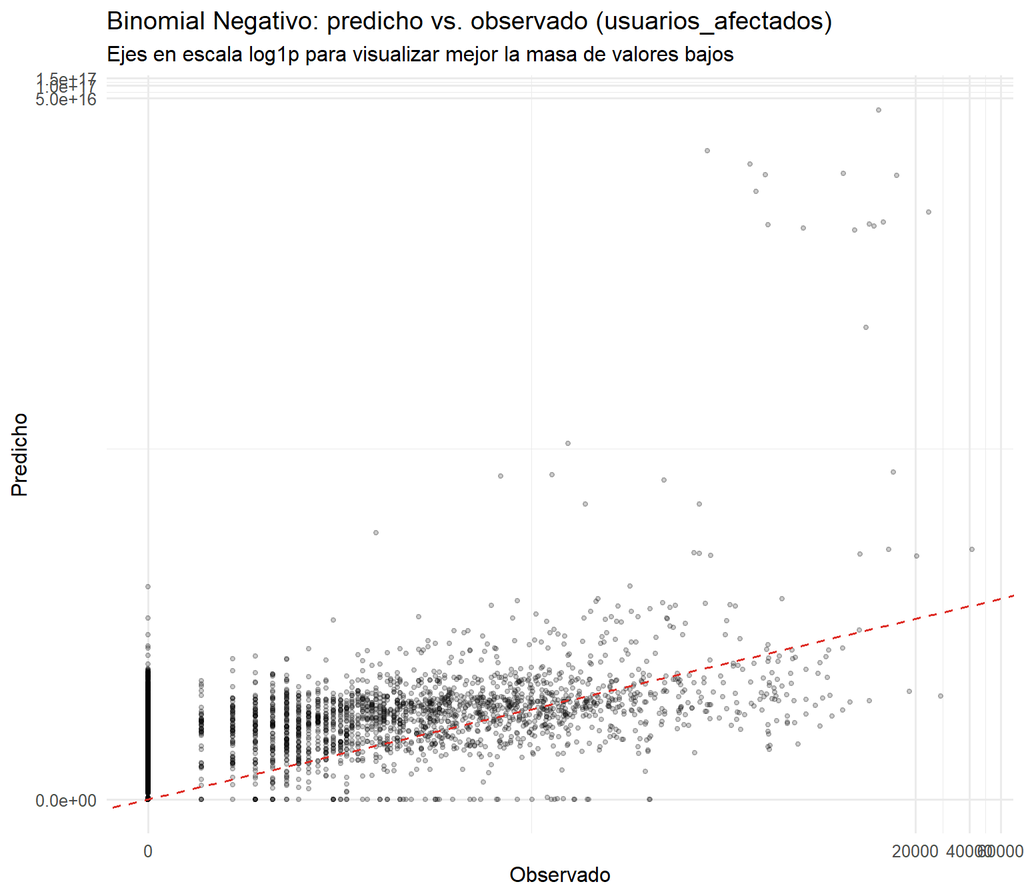

```r
data.frame(
  observado = test_conteo_completo$usuarios_afectados,
  predicho  = pred_binomneg
) %>%
  ggplot(aes(x = observado, y = predicho)) +
  geom_point(alpha = 0.2, size = 1) +
  geom_abline(slope = 1, intercept = 0, color = "#de2d26", linetype = "dashed") +
  scale_x_continuous(trans = "log1p") +
  scale_y_continuous(trans = "log1p") +
  labs(
    title    = "Binomial Negativo: predicho vs. observado (usuarios_afectados)",
    subtitle = "Ejes en escala log1p para visualizar mejor la masa de valores bajos",
    x = "Observado", y = "Predicho"
  ) +
  theme_minimal(base_size = 12)
```